# Evaluation of published TB signatures and Indian TB/LTBI signature

Samantha Leong, Yue Zhao, W. Evan Johnson, Padmini Salgame

Computational Biomedicine, Boston University

04 January, 2018

##### Note: Please click the “Code” button in upper right corner, and choose “Hide All Code”

### Introduction

- Notations:
  - control: Not progressed latent TB infected (LTBI)
  - IC: Already progressed
- Data:
  - Indian 1: 16 controls, 16 IC
  - Indian 2: 12 IC
  - In total: 16 controls, 28 IC
- Reference Signatures
  - jacobsen2007_3gene
  - sweeney2016_3gene
  - berry2010_393gene
  - berry2010_86gene
  - zak2016_16gene

### Plan

- Process RNA-seq data
- EDA(PCA)
- Differential expression analysis
- compare the DEGs under different cut-offs with published signatures
- Normalize the data using deseq
- correct the gender batch using combat
- test the unsupervised clustering performance using published signatures (PCA, tSNE, MDS)
- Use LOO Jackknife to compare the AUC between signatures

# Load packages

```r
#library
library(ggplot2)
library(DESeq2)
library(sva)
library(pheatmap)
library(tsne)
library(Rtsne)
require(bioDist)
require(glmnet)
require(readr)
#load R_lib_jason
library(R.utils)
require(boot)
require(gmodels)
sourceDirectory("../../R_lib_jason/", modifiedOnly=TRUE)
```

### EDA: exploratory data analysis

### PCA Before Batch Adjust

#### PCA on raw counts

```r
#PCA from raw counts (naive approach)
plot_PCA_new(IndianData, condition = treatmentsIndian, useVST = FALSE, pointSize = 4, useLabel = F)
plot_PCA_new(IndianData, condition = treatmentsIndian, useVST = FALSE, pointSize = 3, useLabel = T)
plot_PCA_new(IndianData, condition = genderIndian, useVST = FALSE, pointSize = 4, useLabel = F)
plot_PCA_new(IndianData, condition = genderIndian, useVST = FALSE, pointSize = 3, useLabel = T)


#pdf
#plot_PCA_new(IndianData, condition = treatmentsIndian, useVST = FALSE, pointSize = 4, useLabel = F ,outputPDF = T, outputName = "PCA_raw.pdf", title = "Raw data PCA plot")
```

#### PCA on deseq2_RLE normalization

```r
#BSN: between sample normalization
#RLE: relative log expression method from DESeq2
IndianData_rle <- deseq2_norm_rle(IndianData)
#write.csv(IndianData_rle, "../normalized_counts_matrix.csv",quote = F)

#plot
plot_PCA_new(IndianData_rle, condition = treatmentsIndian, useVST = FALSE, pointSize = 4, useLabel = F)
plot_PCA_new(IndianData_rle, condition = treatmentsIndian, useVST = FALSE, pointSize = 3, useLabel = T)
plot_PCA_new(IndianData_rle, condition = genderIndian, useVST = FALSE, pointSize = 4, useLabel = F)
plot_PCA_new(IndianData_rle, condition = genderIndian, useVST = FALSE, pointSize = 3, useLabel = T)
```

#### PCA on log2-transformation on raw counts

```r
IndianData_log2 <- log2(IndianData + 0.1)

#plot
plot_PCA_new(IndianData_log2, condition = treatmentsIndian, useVST = FALSE, pointSize = 4, useLabel = F)
plot_PCA_new(IndianData_log2, condition = treatmentsIndian, useVST = FALSE, pointSize = 3, useLabel = T)
plot_PCA_new(IndianData_log2, condition = genderIndian, useVST = FALSE, pointSize = 4, useLabel = F)
plot_PCA_new(IndianData_log2, condition = genderIndian, useVST = FALSE, pointSize = 3, useLabel = T)
```

#### PCA from RLE and then log2 transform

```r
#PCA from RLE and then log2 transform: found 4 outliers
IndianData_rle <- deseq2_norm_rle(IndianData)
IndianData_rle_log2 <- log2(IndianData_rle + 0.1)

#plot
plot_PCA_new(IndianData_rle_log2, condition = treatmentsIndian, useVST = FALSE, pointSize = 4, useLabel = F)
plot_PCA_new(IndianData_rle_log2, condition = treatmentsIndian, useVST = FALSE, pointSize = 3, useLabel = T)
plot_PCA_new(IndianData_rle_log2, condition = genderIndian, useVST = FALSE, pointSize = 4, useLabel = F)
plot_PCA_new(IndianData_rle_log2, condition = genderIndian, useVST = FALSE, pointSize = 3, useLabel = T)
```

#### PCA from raw counts: remove outliers

```r
#PCA from raw counts: remove outliers
plot_PCA_new(IndianData[,-c(37,44,34,41)], condition = treatmentsIndian[-c(37,44,34,41)], useVST = FALSE, pointSize = 4, useLabel = F)
plot_PCA_new(IndianData[,-c(37,44,34,41)], condition = treatmentsIndian[-c(37,44,34,41)], useVST = FALSE, pointSize = 3, useLabel = T)
plot_PCA_new(IndianData[,-c(37,44,34,41)], condition = genderIndian[-c(37,44,34,41)], useVST = FALSE, pointSize = 4, useLabel = F)
plot_PCA_new(IndianData[,-c(37,44,34,41)], condition = genderIndian[-c(37,44,34,41)], useVST = FALSE, pointSize = 3, useLabel = T)
```

#### PCA from rle deseq normalized counts: remove outliers

```r
#PCA from rle deseq normalized counts: remove outliers
plot_PCA_new(IndianData_rle[,-c(37,44,34,41)], condition = treatmentsIndian[-c(37,44,34,41)], useVST = FALSE, pointSize = 4, useLabel = F)
plot_PCA_new(IndianData_rle[,-c(37,44,34,41)], condition = treatmentsIndian[-c(37,44,34,41)], useVST = FALSE, pointSize = 3, useLabel = T)
plot_PCA_new(IndianData_rle[,-c(37,44,34,41)], condition = genderIndian[-c(37,44,34,41)], useVST = FALSE, pointSize = 4, useLabel = F)
plot_PCA_new(IndianData_rle[,-c(37,44,34,41)], condition = genderIndian[-c(37,44,34,41)], useVST = FALSE, pointSize = 3, useLabel = T)
```

#### PCA from rle deseq normalized counts: remove outliers + top 500 genes

```r
#PCA from rle deseq normalized counts: remove outliers
plot_PCA_new(IndianData_rle[,-c(37,44,34,41)], condition = treatmentsIndian[-c(37,44,34,41)], useVST = FALSE, pointSize = 4, useLabel = F, useAllFeature = FALSE, nFeature = 500)
plot_PCA_new(IndianData_rle[,-c(37,44,34,41)], condition = treatmentsIndian[-c(37,44,34,41)], useVST = FALSE, pointSize = 3, useLabel = T, useAllFeature = FALSE, nFeature = 500)
plot_PCA_new(IndianData_rle[,-c(37,44,34,41)], condition = genderIndian[-c(37,44,34,41)], useVST = FALSE, pointSize = 4, useLabel = F, useAllFeature = FALSE, nFeature = 500)
plot_PCA_new(IndianData_rle[,-c(37,44,34,41)], condition = genderIndian[-c(37,44,34,41)], useVST = FALSE, pointSize = 3, useLabel = T, useAllFeature = FALSE, nFeature = 500)
```

#### PCA from log2-tranformed counts: remove outliers

```r
#PCA from log2-transformed counts: remove outliers
plot_PCA_new(IndianData_log2[,-c(37,44,34,41)], condition = treatmentsIndian[-c(37,44,34,41)], useVST = FALSE, pointSize = 4, useLabel = F)
plot_PCA_new(IndianData_log2[,-c(37,44,34,41)], condition = treatmentsIndian[-c(37,44,34,41)], useVST = FALSE, pointSize = 3, useLabel = T)
plot_PCA_new(IndianData_log2[,-c(37,44,34,41)], condition = genderIndian[-c(37,44,34,41)], useVST = FALSE, pointSize = 4, useLabel = F)
plot_PCA_new(IndianData_log2[,-c(37,44,34,41)], condition = genderIndian[-c(37,44,34,41)], useVST = FALSE, pointSize = 3, useLabel = T)
```

#### PCA from log2-tranformed deseq normalized counts: remove outliers

```r
plot_PCA_new(IndianData_rle_log2[,-c(37,44,34,41)], condition = treatmentsIndian[-c(37,44,34,41)], useVST = FALSE, pointSize = 4, useLabel = F)
plot_PCA_new(IndianData_rle_log2[,-c(37,44,34,41)], condition = treatmentsIndian[-c(37,44,34,41)], useVST = FALSE, pointSize = 3, useLabel = T)
plot_PCA_new(IndianData_rle_log2[,-c(37,44,34,41)], condition = genderIndian[-c(37,44,34,41)], useVST = FALSE, pointSize = 4, useLabel = F)
plot_PCA_new(IndianData_rle_log2[,-c(37,44,34,41)], condition = genderIndian[-c(37,44,34,41)], useVST = FALSE, pointSize = 3, useLabel = T)
```

#### VST on Indian Dataset

```r
#use all genes
plot_PCA_new(sampleDataFrame = IndianData,condition = genderIndian)

#use top high variance 1000 genes
plot_PCA_new(sampleDataFrame = IndianData,condition = genderIndian, useAllFeature = FALSE, nFeature = 1000, title = "PCA plot for top 1k high variance genes")

#use all genes
plot_PCA_new(sampleDataFrame = IndianData,condition = treatmentsIndian)


#use top high variance 1000 genes
plot_PCA_new(sampleDataFrame = IndianData,condition = treatmentsIndian, useAllFeature = FALSE, nFeature = 1000, title = "PCA plot for top 1k high variance genes")
```

#### VST on Indian Dataset: remove outliers

```r
#use all genes
plot_PCA_new(sampleDataFrame = IndianData[,-c(37,44,34,41)],condition = genderIndian[-c(37,44,34,41)])

#use top high variance 1000 genes
plot_PCA_new(sampleDataFrame = IndianData[,-c(37,44,34,41)],condition = genderIndian[-c(37,44,34,41)], useAllFeature = FALSE, nFeature = 1000, title = "PCA plot for top 1k high variance genes")

#use all genes
plot_PCA_new(sampleDataFrame = IndianData[,-c(37,44,34,41)],condition = treatmentsIndian[-c(37,44,34,41)])


#use top high variance 1000 genes
plot_PCA_new(sampleDataFrame = IndianData[,-c(37,44,34,41)],condition = treatmentsIndian[-c(37,44,34,41)], useAllFeature = FALSE, nFeature = 1000, title = "PCA plot for top 1k high variance genes")
```

### Summary from the EDA

- filter the genes with max read counts less or equal to 20.
- 4 outliers:10200060A-Male, 10200087A-Female,10200288A-Female,10200112A-Female
- We compared the effects of using deseq rle normalization, log-2 transformation, rle-log2 method, variance-stablizing-transformation, with or without top high variance genes, with or without outliers removal.
- The best approach for now: deseq rle normalization + full genes + 4 outliers removal.
- After read max count filtering for genes and sample outliers removal.

### Differential Expression

```r
#Differential Expression

#remove the outliers
IndianData_filtered <- IndianData[,-c(37,44,34,41)]
genderIndian_filtered <- genderIndian[-c(37,44,34,41)]
treatmentsIndian_filtered <- treatmentsIndian[-c(37,44,34,41)]




# dds structure
colDataIndian <- data.frame(condition = treatmentsIndian_filtered, gender = genderIndian_filtered)
rownames(colDataIndian) <- colnames(IndianData_filtered)
#Add gender info later when available
ddsIndian <- DESeqDataSetFromMatrix(countData = IndianData_filtered,
                                colData = colDataIndian,
                                design = ~ condition + gender)
ddsIndian <- estimateSizeFactors(ddsIndian)
```

### DE summary

```r
pdf("overlap.pdf", width = 12, height = 10)
ggplot(data = df_percent, aes(x = cutoff, y = percentage, color = name)) + geom_point() + geom_line() + labs(list(title = "Indian Data DE Genes Overlap", x = "DE analysis cut-off, padj < 10e-x", y = "Percentage overlapped")) + scale_x_discrete(limits=c(seq(1,n,1))) + ylim(0,1) + theme(text = element_text(size=20)) +  ggtitle("Indian Data DE Genes Overlap") + theme(plot.title = element_text(hjust = 0.5))
dev.off()
```

### Heatmap for DE genes

- Cut-off: padj < 0.01, |LFC| > 1

```r
library(RColorBrewer)

#We already get the deseq_rle_normalized data: IndianData_rle
# remove the outliers:
IndianData_final <- IndianData_rle[,-c(37,44,34,41)]

colnames(IndianData_final)[5] <- "A000136-Male-relapse"
colnames(IndianData_final)[38] <- "10200111A-Male-fail"

labelIndianData_final <- c(rep("TB", 16), rep("control", 16), rep("TB", 8))



##################################################
#DE genes heatmap using normlized data, p-value < 1e-2
####################################################


resSig <- subset(resIndianOrdered, padj < 1e-2)
resSig.up <- subset(resSig, log2FoldChange > 1)
resSig.down <- subset(resSig, log2FoldChange < -1)
up <- rownames(resSig.up)
down <- rownames(resSig.down)
DEG_tmp <- c(up, down)


plot_pheatmap(IndianData_final[DEG_tmp,], labelIndianData_final,colorGroup = c(TB = "red", control = "green"), title = "Row-scaled Log2-transformed DEG (p-value<1e-2) Heatmap", log2Trans = T, rowScaling = T, showRowName = F, showColName = F, outputPDF = T, outputName = "DEG_1e-2_heatmap.pdf", height = 8, width = 9)


##################################################
#DE genes heatmap using normlized data, p-value < 1e-10
####################################################


resSig.1e10 <- subset(resIndianOrdered, padj < 1e-10)
resSig.up.1e10 <- subset(resSig.1e10, log2FoldChange > 1)
resSig.down.1e10 <- subset(resSig.1e10, log2FoldChange < -1)
up.1e10 <- rownames(resSig.up.1e10)
down.1e10 <- rownames(resSig.down.1e10)
DEG.1e10 <- c(up.1e10, down.1e10)


plot_pheatmap(IndianData_final[DEG.1e11,], labelIndianData_final,colorGroup = c(TB = "red", control = "green"), title = "Row-scaled Log2-transformed DEG (p-value<1e-11) Heatmap", log2Trans = T, rowScaling = T, showColName = F, outputPDF = T, outputName = "DEG_1e-11_heatmap.pdf", height = 10, width = 9)
```

```r
# prepare gene list
berry2010_393gene_exist <- intersect(fullGene, berry2010_393gene)
berry2010_86gene_exist <- intersect(fullGene, berry2010_86gene)

# some genes from berry 266, not in Indian_final,
# as they are filtered before!
filtered_gene_393 <- berry2010_393gene_exist[which(!(berry2010_393gene_exist %in% rownames(IndianData_final)))]

berry2010_393gene_exist_overlap <- berry2010_393gene_exist[which(berry2010_393gene_exist %in% rownames(IndianData_final))]
```

### Quantitatively Evaluation of published signatures by Logistic Regression CV

```r
signatureNameALL <- c("Zak-16", "Jacobsen-3", "sweeney-3", "Berry-264", "Berry-65")
metricNameAll <- c("AUC", "Accuracy","Pearson", "Kendall-Tau Distance")

#Simple Logistic regression, no regularization
###############


LOOCV_zak16_simple <- LOOCV_Glmnet_simple(IndianData_final[zak2016_16gene,], labelIndianData_final, logisticRegression = TRUE, useAUC = TRUE, useHamming = TRUE, useKendallTau = TRUE)

LOOCV_jacobsen3_simple <- LOOCV_Glmnet_simple(IndianData_final[jacobsen2007_3gene,], labelIndianData_final, logisticRegression = TRUE, useAUC = TRUE, useHamming = TRUE, useKendallTau = TRUE)

LOOCV_sweeney3_simple <- LOOCV_Glmnet_simple(IndianData_final[sweeney2016_3gene,], labelIndianData_final, logisticRegression = TRUE,useAUC = TRUE, useHamming = TRUE, useKendallTau = TRUE)

LOOCV_berry264_simple <- LOOCV_Glmnet_simple(IndianData_final[berry2010_393gene_exist_overlap,], labelIndianData_final, logisticRegression = TRUE, useAUC = TRUE, useHamming = TRUE, useKendallTau = TRUE)

LOOCV_berry65_simple <- LOOCV_Glmnet_simple(IndianData_final[berry2010_86gene_exist,], labelIndianData_final, logisticRegression = TRUE, useAUC = TRUE, useHamming = TRUE, useKendallTau = TRUE)

LOOCV_indian24_simple <- LOOCV_Glmnet_simple(IndianData_final[signature.lasso.multiple,], labelIndianData_final, logisticRegression = TRUE, useAUC = TRUE, useHamming = TRUE, useKendallTau = TRUE)

output.loocv <- list(LOOCV_zak16_simple, LOOCV_jacobsen3_simple, LOOCV_sweeney3_simple, LOOCV_berry264_simple, LOOCV_berry65_simple)

AUC_loocv <- sapply(output.loocv, function(x) x[1])
ACC_loocv <- sapply(output.loocv, function(x) x[3])
Tau_loocv <- sapply(output.loocv, function(x) x[4])
df.loocv <- data.frame(AUC_loocv, ACC_loocv, Tau_loocv)
colnames(df.loocv) <- c("AUC", "Accuracy", "Kendall Tau Distance")
rownames(df.loocv) <- signatureNameALL

write.csv(x = df.loocv, file = "../LOOCV_stat.csv")


loocv.ggplot.df <- data.frame()
count <- 1
for (i in 1:nrow(df.loocv)){
  for (j in 1:ncol(df.loocv)){
    tmp <- c(round(df.loocv[i,j],3), colnames(df.loocv)[j], rownames(df.loocv)[i])
    loocv.ggplot.df[count,1] <- tmp[1]
    loocv.ggplot.df[count,2] <- tmp[2]
    loocv.ggplot.df[count,3] <- tmp[3]
    count <- count + 1
  }

}
colnames(loocv.ggplot.df) <- c("Value", "Metric", "Signature")


#ggplot
ggplot(data = loocv.ggplot.df,aes(x=Signature, y=Value, color=Metric)) + geom_point(size=6) + ggtitle("Comparion of TB signatures from leave-one-out cross-validation") + theme(plot.title = element_text(hjust = 0.5))
ggsave("signatureComparison.pdf", width = 25, height = 20, units = "cm")













#Ridge Logistic regression
#####################
# use labelIndianData_final

set.seed(20)

# LOOCV
LOOCV_zak16 <- LOOCV_Glmnet_ridge(IndianData_final[zak2016_16gene,], labelIndianData_final, logisticRegression = TRUE, nfolds = 3, nTimes = 100, useAUC = TRUE, useHamming = TRUE, useKendallTau = TRUE)

LOOCV_jacobsen3 <- LOOCV_Glmnet_ridge(IndianData_final[jacobsen2007_3gene,], labelIndianData_final, logisticRegression = TRUE, nfolds = 3, nTimes = 100, useAUC = TRUE, useHamming = TRUE, useKendallTau = TRUE)

LOOCV_sweeney3 <- LOOCV_Glmnet_ridge(IndianData_final[sweeney2016_3gene,], labelIndianData_final, logisticRegression = TRUE, nfolds = 3, nTimes = 100, useAUC = TRUE, useHamming = TRUE, useKendallTau = TRUE)

LOOCV_berry264 <- LOOCV_Glmnet_ridge(IndianData_final[berry2010_393gene_exist_overlap,], labelIndianData_final, logisticRegression = TRUE, nfolds = 3, nTimes = 100, useAUC = TRUE, useHamming = TRUE, useKendallTau = TRUE)

LOOCV_berry65 <- LOOCV_Glmnet_ridge(IndianData_final[berry2010_86gene_exist,], labelIndianData_final, logisticRegression = TRUE, nfolds = 3, nTimes = 100, useAUC = TRUE, useHamming = TRUE, useKendallTau = TRUE)


LOOCV_indian24 <- LOOCV_Glmnet_ridge(IndianData_final[signature.lasso.multiple,], labelIndianData_final, logisticRegression = TRUE, nfolds = 3, nTimes = 100, useAUC = TRUE, useHamming = TRUE, useKendallTau = TRUE)

#
LOOCV_result_list <- list(LOOCV_zak16, LOOCV_jacobsen3, LOOCV_sweeney3, LOOCV_berry264, LOOCV_berry65)
meanAUC <- c()
sdAUC <- c()
meanAccuracy <- c()
sdAccuracy <- c()
meanKendallTauDistance <- c()
sdKendallTauDistance <- c()



for (i in 1:length(LOOCV_result_list)){
  meanAUC[i] <- mean(LOOCV_result_list[[i]][[1]])
  sdAUC[i] <- sd(LOOCV_result_list[[i]][[1]])
  meanAccuracy[i] <- mean(LOOCV_result_list[[i]][[2]])
  sdAccuracy[i] <- sd(LOOCV_result_list[[i]][[2]])
  meanKendallTauDistance[i] <- mean(LOOCV_result_list[[i]][[4]])
  sdKendallTauDistance[i] <- sd(LOOCV_result_list[[i]][[4]])
}

#get table for signature mean and sd in (AUC, acc, kendall-tau)
LOOCV_result <- data.frame(meanAUC, sdAUC, meanAccuracy, sdAccuracy, meanKendallTauDistance, sdKendallTauDistance)
rownames(LOOCV_result) <- c("Zak-16", "Jacobsen-3", "sweeney-3", "Berry-264", "Berry-65")
write.csv(x = LOOCV_result, file = "../LOOCV_stat.csv")



#prepare the df for ggplot
signatureNameALL <- c("Zak-16", "Jacobsen-3", "sweeney-3", "Berry-264", "Berry-65")
metricNameAll <- c("AUC", "Accuracy","Pearson", "Kendall-Tau Distance")

LOOCV_result_ggplotDF <- data.frame()

nCount = 1
for (i in 1:length(LOOCV_result_list)){
  for (j in c(1,2,4)){
    for (k in 1:100){
      LOOCV_result_ggplotDF[nCount,1] <- LOOCV_result_list[[i]][[j]][k]
      LOOCV_result_ggplotDF[nCount,2] <- signatureNameALL[i]
      LOOCV_result_ggplotDF[nCount,3] <- metricNameAll[j]
      nCount <- nCount + 1
    }
  }
}

colnames(LOOCV_result_ggplotDF) <- c("MetricValue", "Signatures", "MetricName")
LOOCV_result_ggplotDF$Signatures <- factor(LOOCV_result_ggplotDF$Signatures)
LOOCV_result_ggplotDF$MetricName <- factor(LOOCV_result_ggplotDF$MetricName)

#ggplot
ggplot(data = LOOCV_result_ggplotDF,aes(x=Signatures, y=MetricValue, fill=MetricName)) + geom_boxplot() + ggtitle("Comparion of TB signatures from 100 runs Leave-one-out cross-validation") + theme(plot.title = element_text(hjust = 0.5))

ggsave("signatureComparison_ridge.pdf", width = 25, height = 20, units = "cm")
```

### Unsupervised Evaluation by TSNE

1. Row-scaled Log2-trandformed normalized counts heatmap
2. Pearson correlation heatmap
3. PCA
4. t-SNE

#### Maertzdorf 4 gene signature

[output not shown]

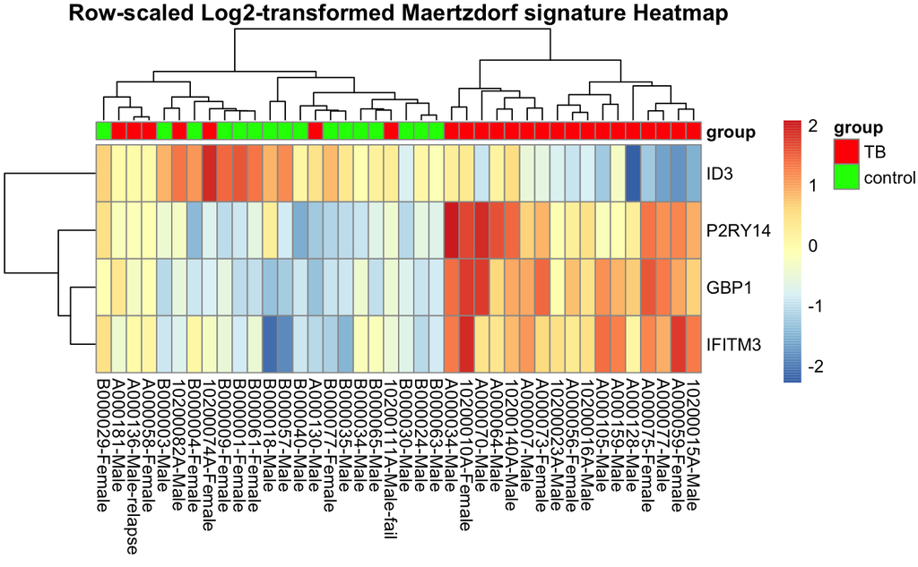

```r
plot_pheatmap(IndianData_final[maertzdorf_4gene,], labelIndianData_final,colorGroup = c(TB = "red", control = "green"), title = "Row-scaled Log2-transformed Maertzdorf signature Heatmap", log2Trans = T, rowScaling = T, showColName = T, outputPDF = T, outputName = "Maertzdorf_heatmap.pdf", height = 8, width = 9)
```

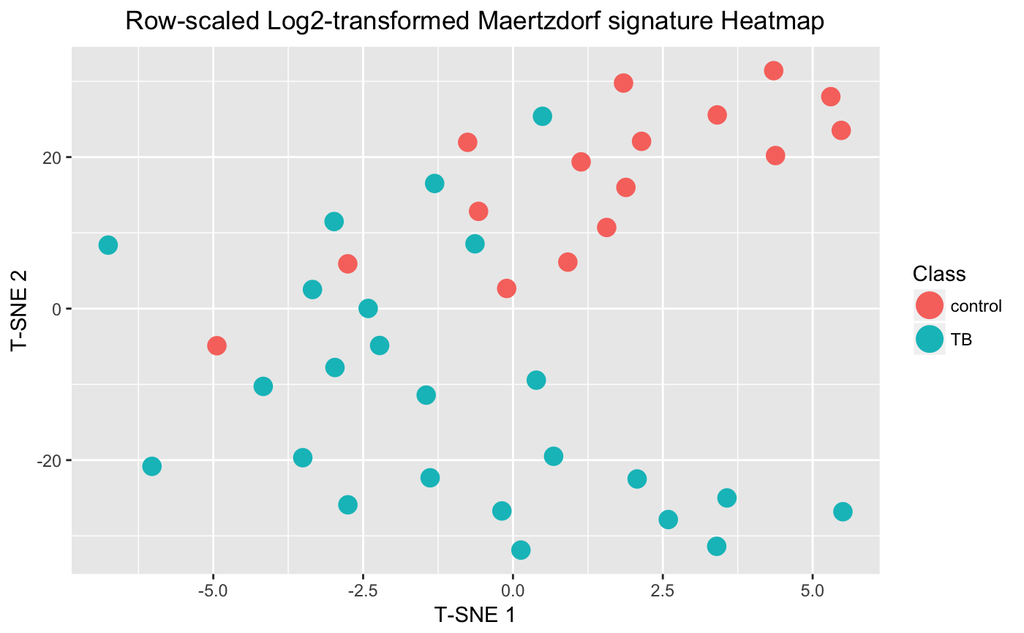

```r
plot_tsne(IndianData_final[maertzdorf_4gene,], labelIndianData_final,title = "Row-scaled Log2-transformed Maertzdorf signature Heatmap", outputPDF = TRUE, outputName = "Maertzdorf_tsne.pdf", height = 14, width = 16)
```

#### Sambarey 10 gene signature

[output not shown]

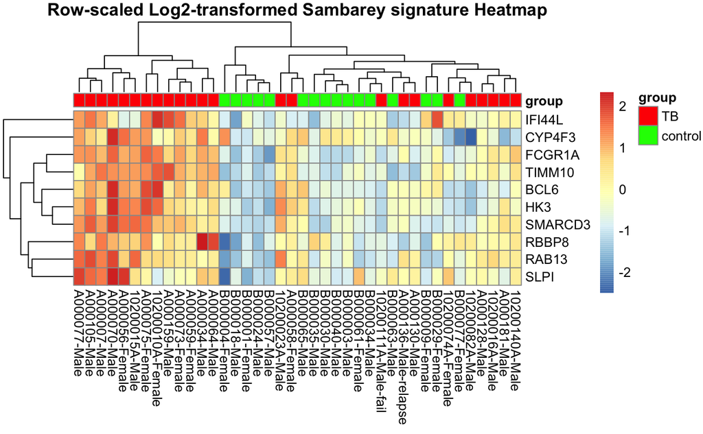

```r
plot_pheatmap(IndianData_final[sambarey_10gene,], labelIndianData_final,colorGroup = c(TB = "red", control = "green"), title = "Row-scaled Log2-transformed Sambarey signature Heatmap", log2Trans = T, rowScaling = T, showColName = T, outputPDF = T, outputName = "Sambarey_heatmap.pdf", height = 8, width = 9)
```

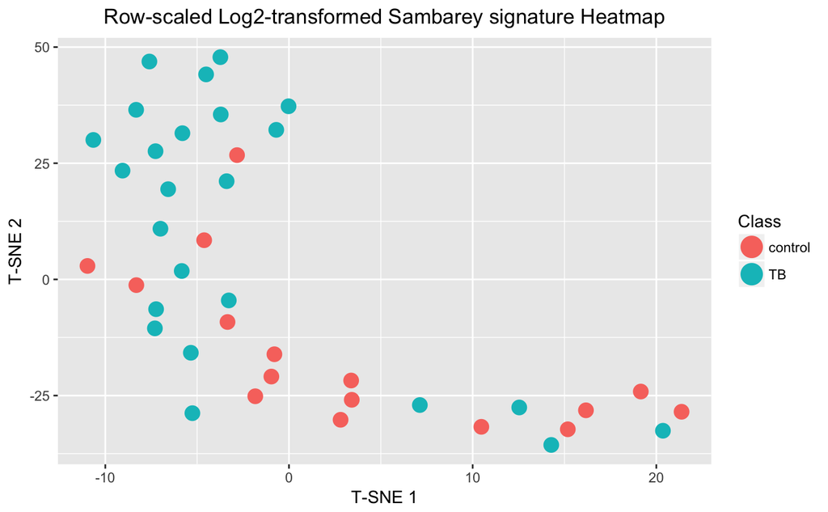

```r
plot_tsne(IndianData_final[sambarey_10gene,], labelIndianData_final,title = "Row-scaled Log2-transformed Sambarey signature Heatmap", outputPDF = TRUE, outputName = "Sambarey_tsne.pdf", height = 14, width = 16)
```

#### Kaforou 27 gene signature

```r
ggList <- plot_visualization(IndianData_final[Kaforou.27,], labelIndianData_final, dataName = "Kaforou 27 gene", log2Trans = TRUE, colorGroup = c(TB = "red", control = "green"), useLabel = FALSE, pdfOutput = TRUE)
ggList[[1]]
ggList[[2]]






#final pdf output: heatmap and tsne

plot_pheatmap(IndianData_final[Kaforou.27,], labelIndianData_final,colorGroup = c(TB = "red", control = "green"), title = "Row-scaled Log2-transformed Kaforou signature Heatmap", log2Trans = T, rowScaling = T, showColName = T, outputPDF = T, outputName = "Kaforou_heatmap.pdf", height = 8, width = 9)

plot_tsne(IndianData_final[Kaforou.27,], labelIndianData_final,title = "Row-scaled Log2-transformed Kaforou signature Heatmap", outputPDF = TRUE, outputName = "Kaforou_tsne.pdf", height = 14, width = 16)
```

#### Zak 16 gene signature

```r
ggList <- plot_visualization(IndianData_final[zak2016_16gene,], labelIndianData_final, dataName = "zak 16 gene", log2Trans = TRUE, colorGroup = c(TB = "red", control = "green"), useLabel = FALSE, pdfOutput = TRUE)
ggList[[1]]
ggList[[2]]






#final pdf output: heatmap and tsne

plot_pheatmap(IndianData_final[zak2016_16gene,], labelIndianData_final,colorGroup = c(TB = "red", control = "green"), title = "Row-scaled Log2-transformed Zak signature Heatmap", log2Trans = T, rowScaling = T, showColName = F, outputPDF = T, outputName = "Zak_heatmap.pdf", height = 8, width = 9)

plot_tsne(IndianData_final[zak2016_16gene,], labelIndianData_final,title = "Row-scaled Log2-transformed Zak signature Heatmap", outputPDF = TRUE, outputName = "Zak_tsne.pdf", height = 14, width = 16)
```

#### Jacobsen 3 gene signature

```r
ggList <- plot_visualization(IndianData_final[jacobsen2007_3gene,], labelIndianData_final, dataName = "jacobsen 3 gene", log2Trans = TRUE, colorGroup = c(TB = "red", control = "green"), useLabel = FALSE, pdfOutput = TRUE)
ggList[[1]]
ggList[[2]]

#final pdf output: heatmap and tsne

plot_pheatmap(IndianData_final[jacobsen2007_3gene,], labelIndianData_final,colorGroup = c(TB = "red", control = "green"), title = "Row-scaled Log2-transformed Jacobsen signature Heatmap", log2Trans = T, rowScaling = T, showColName = F, outputPDF = T, outputName = "Jacobsen_heatmap.pdf", height = 8, width = 9)

plot_tsne(IndianData_final[jacobsen2007_3gene,], labelIndianData_final,title = "Row-scaled Log2-transformed Jacobsen signature Heatmap", outputPDF = TRUE, outputName = "Jacobsen_tsne.pdf", height = 14, width = 16)
```

#### sweeney 3 gene signature

```r
ggList <- plot_visualization(IndianData_final[sweeney2016_3gene,], labelIndianData_final, dataName = "sweeney 3 gene", log2Trans = TRUE, colorGroup = c(TB = "red", control = "green"), useLabel = FALSE, pdfOutput = TRUE)
ggList[[1]]
ggList[[2]]

#final pdf output: heatmap and tsne

plot_pheatmap(IndianData_final[sweeney2016_3gene,], labelIndianData_final,colorGroup = c(TB = "red", control = "green"), title = "Row-scaled Log2-transformed Sweeney signature Heatmap", log2Trans = T, rowScaling = T, showColName = F, outputPDF = T, outputName = "Sweeney_heatmap.pdf", height = 8, width = 9)

plot_tsne(IndianData_final[sweeney2016_3gene,], labelIndianData_final,title = "Row-scaled Log2-transformed Sweeney signature Heatmap", outputPDF = TRUE, outputName = "Sweeney_tsne.pdf", height = 14, width = 16)
```

#### Berry 264 gene signature

```r
ggList <- plot_visualization(IndianData_final[berry2010_393gene_exist_overlap,], labelIndianData_final, dataName = "berry 264 gene", log2Trans = TRUE, colorGroup = c(TB = "red", control = "green"), useLabel = F, pdfOutput = T)
ggList[[1]]
ggList[[2]]

#final pdf output: heatmap and tsne

plot_pheatmap(IndianData_final[berry2010_393gene_exist_overlap,], labelIndianData_final,colorGroup = c(TB = "red", control = "green"), title = "Row-scaled Log2-transformed Berry-393 signature Heatmap", log2Trans = T, rowScaling = T, showColName = F, outputPDF = T, outputName = "Berry-393_heatmap.pdf", height = 8, width = 9)

plot_tsne(IndianData_final[berry2010_393gene_exist_overlap,], labelIndianData_final,title = "Row-scaled Log2-transformed Berry-393 signature Heatmap", outputPDF = TRUE, outputName = "Berry-393_tsne.pdf", height = 14, width = 16)
```

#### Berry 65 gene signature

```r
ggList <- plot_visualization(IndianData_final[berry2010_86gene_exist,], labelIndianData_final, dataName = "berry 65 gene", log2Trans = TRUE, colorGroup = c(TB = "red", control = "green"), useLabel = F, pdfOutput = T)
ggList[[1]]
ggList[[2]]

#final pdf output: heatmap and tsne

plot_pheatmap(IndianData_final[berry2010_86gene_exist,], labelIndianData_final,colorGroup = c(TB = "red", control = "green"), title = "Row-scaled Log2-transformed Berry-86 signature Heatmap", log2Trans = T, rowScaling = T, showColName = F, outputPDF = T, outputName = "Berry-86_heatmap.pdf", height = 8, width = 9)

plot_tsne(IndianData_final[berry2010_86gene_exist,], labelIndianData_final,title = "Row-scaled Log2-transformed Berry-86 signature Heatmap", outputPDF = TRUE, outputName = "Berry-86_tsne.pdf", height = 14, width = 16)
```

#### Indian 24 gene signature

```r
ggList <- plot_visualization(IndianData_final[signature.lasso.multiple,], labelIndianData_final, dataName = "Indian-lasso", log2Trans = TRUE, colorGroup = c(TB = "red", control = "green"), useLabel = F, pdfOutput = T)
ggList[[1]]
ggList[[2]]

#final pdf output: heatmap and tsne

plot_pheatmap(IndianData_final[signature.lasso.multiple,], labelIndianData_final,colorGroup = c(TB = "red", control = "green"), title = "Row-scaled Log2-transformed Indian-lasso signature Heatmap", log2Trans = T, rowScaling = T, showColName = F, outputPDF = T, outputName = "Indian-lasso_heatmap.pdf", height = 8, width = 9)

plot_tsne(IndianData_final[signature.lasso.multiple,], labelIndianData_final,title = "Row-scaled Log2-transformed Indian-lasso signature Heatmap", outputPDF = TRUE, outputName = "Indian-lasso_tsne.pdf", height = 14, width = 16)
```

### LOO Jackknife AUC comparison with plotting

```r
dfList <- list(IndianData_final[zak2016_16gene,], IndianData_final[jacobsen2007_3gene,], IndianData_final[sweeney2016_3gene,], IndianData_final[berry2010_393gene_exist_overlap,],IndianData_final[berry2010_86gene_exist,])
LOOAUC_multiple(dfList, labelIndianData_final_number)

#"red", "blue", "green", "yellow", "black"
signatureNameVec <- c("Zak-16", "Jacobsen-3", "Sweeney-3", "Berry-393", "Berry-86")
pdf("LOO_ROC.pdf", height = 7)
LOOAUC_simple_multiple(dfList, labelIndianData_final_number,signatureNameVec = signatureNameVec, xLegendLocation = 0.5, yLegendLocation = 0.25, title = "ROC from Leave-one-out cross-validation")
dev.off()
```